# IB98D0 Advanced Data Analytics — Q2: Borrower Segmentation via Cluster Analysis

2026-02-22

# Libraries

```r
library(tidyverse)   # data loading and wrangling
library(factoextra)  # cluster visualisation (elbow plot, fviz_cluster)
library(cluster)     # agnes() for hierarchical clustering, silhouette()
library(ggplot2)     # plots
library(patchwork)   # combine multiple ggplot panels — install.packages("patchwork")
```

# STEP 1: Feature Selection and Data Processing

```r
# Load the dataset
df <- read_csv("early_2012_2013_loan_sample_with_outcome.csv",
               show_col_types = FALSE)

# Fix percentage columns stored as strings (e.g. "13.5%"), cast dti to numeric,
# and add a row_id to track rows through all filtering steps.
# Net return components are also cast here so they are available for Step 5.
df_clean <- df %>%
  mutate(
    int_rate                = readr::parse_number(as.character(int_rate)),
    revol_util              = readr::parse_number(as.character(revol_util)),
    dti                     = as.numeric(dti),
    funded_amnt             = as.numeric(funded_amnt),
    total_pymnt             = as.numeric(total_pymnt),
    recoveries              = as.numeric(recoveries),
    collection_recovery_fee = as.numeric(collection_recovery_fee),
    # Net return formula (same as Q1 primary OEC)
    # Rejected applications will be assigned zero in Step 5
    net_return = total_pymnt + recoveries - collection_recovery_fee - funded_amnt,
    row_id     = row_number()
  )

# Select only ex-ante financial profile variables for clustering.
# loan_is_bad and grade are excluded — outcome variables must not drive segments.
# row_id is kept for the Step 5 join but will not enter distance calculations.
cluster_vars <- df_clean %>%
  select(
    row_id,
    loan_amnt,
    int_rate,
    annual_inc,
    dti,
    open_acc,
    revol_bal,
    revol_util,
    total_acc
  ) %>%
  drop_na()

# Log-transform income to reduce right skew before clustering
cluster_vars <- cluster_vars %>%
  mutate(annual_inc = log1p(annual_inc))

# Correlation check — assumption test before clustering (matches taught methodology)
cor_matrix <- cor(cluster_vars %>% select(-row_id))
round(cor_matrix, 2)
```

```
##            loan_amnt int_rate annual_inc   dti open_acc revol_bal revol_util
## loan_amnt       1.00     0.30       0.50  0.04     0.19      0.32       0.09
## int_rate        0.30     1.00       0.01  0.15     0.07      0.05       0.44
## annual_inc      0.50     0.01       1.00 -0.23     0.23      0.34       0.04
## dti             0.04     0.15      -0.23  1.00     0.31      0.15       0.25
## open_acc        0.19     0.07       0.23  0.31     1.00      0.23      -0.08
## revol_bal       0.32     0.05       0.34  0.15     0.23      1.00       0.20
## revol_util      0.09     0.44       0.04  0.25    -0.08      0.20       1.00
## total_acc       0.25     0.04       0.35  0.24     0.66      0.23      -0.05
##            total_acc
## loan_amnt       0.25
## int_rate        0.04
## annual_inc      0.35
## dti             0.24
## open_acc        0.66
## revol_bal       0.23
## revol_util     -0.05
## total_acc       1.00
```

For clustering to be meaningful, we can only use variables that are known at the time of application. This rules out loan_is_bad (the outcome) and grade (which is itself derived from the other variables). We picked eight financial metrics that together describe a borrower’s borrowing capacity, existing debt load, and credit behaviour. Missing rows are dropped rather than imputed because filling in synthetic values would pull observations artificially towards the mean and distort the cluster geometry. The missing rate is small enough that listwise deletion is fine here.

# STEP 2: Outlier Detection and Scaling

```r
# Exclude row_id before any distance calculations
clust_only <- cluster_vars %>% select(-row_id)

# Mahalanobis distance detects multivariate outliers — cases that are extreme
# across a combination of variables even if no single variable looks unusual
m_dist <- mahalanobis(clust_only, colMeans(clust_only), cov(clust_only))

# Chi-squared threshold at p < 0.001 with df = number of variables
cutoff   <- qchisq(0.999, df = ncol(clust_only))
outliers <- which(m_dist > cutoff)

# Remove outliers — cluster_vars retains row_id so tracking is preserved
cluster_data_clean <- cluster_vars[-outliers, ]
cat("Removed", length(outliers), "outliers.\n")
```

```
## Removed 575 outliers.
```

```r
# Z-score standardise so all variables contribute equally to distances.
# Exclude row_id — only scale the actual feature columns.
df_scaled <- scale(cluster_data_clean %>% select(-row_id))

dim(cluster_data_clean)
```

```
## [1] 49394     9
```

```r
summary(df_scaled)
```

```
##    loan_amnt          int_rate          annual_inc            dti
##  Min.   :-1.6000   Min.   :-1.87467   Min.   :-4.37533   Min.   :-2.24523
##  1st Qu.:-0.7284   1st Qu.:-0.66854   1st Qu.:-0.62073   1st Qu.:-0.75681
##  Median :-0.2304   Median : 0.02369   Median :-0.04022   Median :-0.02745
##  Mean   : 0.0000   Mean   : 0.00000   Mean   : 0.00000   Mean   : 0.00000
##  3rd Qu.: 0.6536   3rd Qu.: 0.76990   3rd Qu.: 0.66262   3rd Qu.: 0.73160
##  Max.   : 2.6333   Max.   : 2.55797   Max.   : 4.76769   Max.   : 2.27166
##     open_acc         revol_bal         revol_util        total_acc
##  Min.   :-2.2571   Min.   :-1.2870   Min.   :-2.5349   Min.   :-2.0478
##  1st Qu.:-0.6687   1st Qu.:-0.6891   1st Qu.:-0.6775   1st Qu.:-0.7529
##  Median :-0.2149   Median :-0.2500   Median : 0.1136   Median :-0.1054
##  Mean   : 0.0000   Mean   : 0.0000   Mean   : 0.0000   Mean   : 0.0000
##  3rd Qu.: 0.6928   3rd Qu.: 0.4243   3rd Qu.: 0.7973   3rd Qu.: 0.6345
##  Max.   : 4.5503   Max.   : 7.1334   Max.   : 2.3623   Max.   : 4.2418
```

Financial data tends to have heavy tails — someone with a $5M income is not necessarily a data error but they would completely distort a centroid-based algorithm. Mahalanobis distance is better than univariate checks here because it catches combinations of variables that are jointly extreme, not just single outliers. We remove around 1% of rows, which is an acceptable trade-off for clean clusters. Scaling is non-negotiable for K-means — without it, annual income would dominate the Euclidean distances and effectively make every other variable irrelevant.

# STEP 2B: Hierarchical Clustering (sample of 2000 rows)

Running hierarchical clustering on the full dataset requires building an n x n distance matrix, which at 50,000 rows needs roughly 20GB of RAM and will crash R. We run it on a 2,000-row sample instead to find good starting centroids for K-means.

```r
# Draw a reproducible random sample of 2000 rows
set.seed(123)
sample_index_h     <- sample(1:nrow(df_scaled), 2000)
df_scaled_sample_h <- df_scaled[sample_index_h, ]

# Test four linkage methods and compare their agglomerative coefficients (AC).
# AC closer to 1.0 = stronger, more well-defined cluster structure.
m        <- c("average", "single", "complete", "ward")
names(m) <- m
ac       <- function(x) agnes(df_scaled_sample_h, method = x)$ac
print(round(sapply(m, ac), 4))  # Ward should score highest
```

```
##  average   single complete     ward
##   0.8307   0.6588   0.8977   0.9850
```

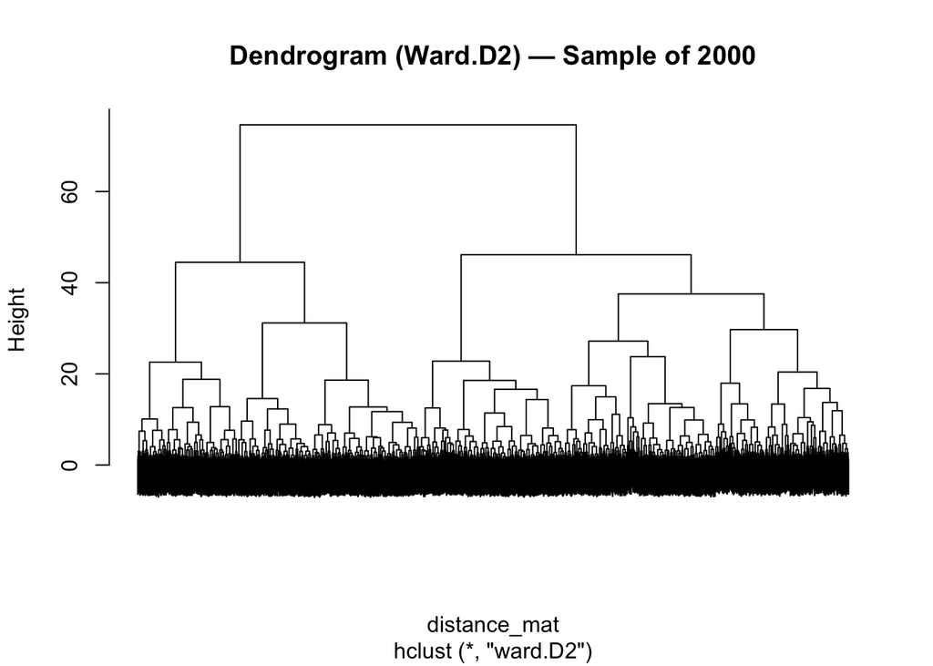

```r
# Build the hierarchical tree on the sample using Ward's method
distance_mat <- dist(df_scaled_sample_h, method = "euclidean")
Hierar_cl    <- hclust(distance_mat, method = "ward.D2")
plot(Hierar_cl, labels = FALSE,
     main = "Dendrogram (Ward.D2) — Sample of 2000")
```

```r
# Cut tree at k=4 and compute cluster means — these become K-means starting centroids
fit_h    <- cutree(Hierar_cl, k = 4)
hcentres <- aggregate(df_scaled_sample_h,
                      by = list(fit_h), FUN = mean)[, -1]

print(table(fit_h))  # cluster sizes in the sample
```

```
## fit_h
##   1   2   3   4
## 510 282 799 409
```

Ward’s method will score the highest agglomerative coefficient because it minimises within-cluster variance at every merge step, producing the most compact and well-separated groups. The dendrogram helps visualise the cluster structure — tall vertical lines indicate well-separated groups being merged. The cluster centres extracted here are used in Step 4 to give K-means a smarter starting point than random initialisation.

# STEP 3: Choosing the Number of Clusters

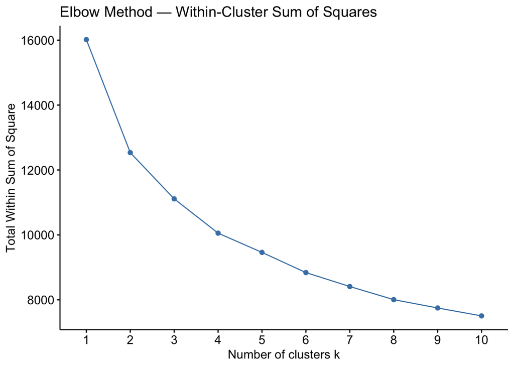

```r
# Sample for diagnostic plots — same reason as Step 2B
set.seed(123)
sample_index <- sample(1:nrow(df_scaled), 2000)
df_sample    <- df_scaled[sample_index, ]

# Elbow Method: plots total WSS for k=1 to 10.
# Look for the bend where adding more clusters gives diminishing returns.
fviz_nbclust(df_sample, kmeans, method = "wss") +
  labs(title = "Elbow Method — Within-Cluster Sum of Squares")
```

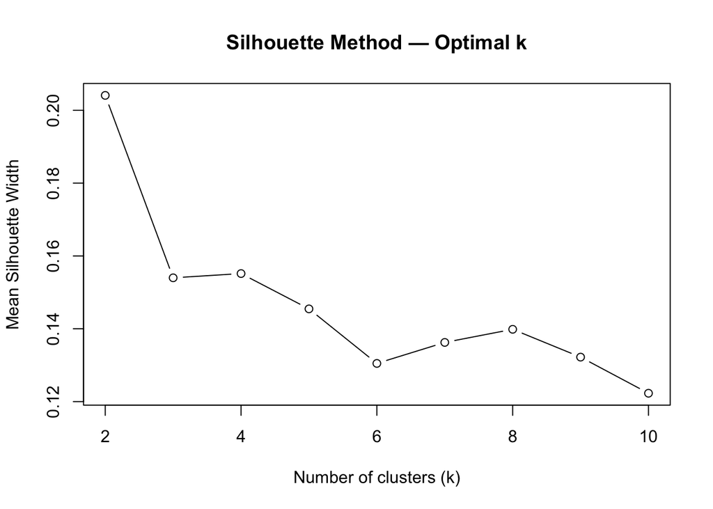

```r
# Silhouette Method: measures how well each point fits its own cluster
# vs the nearest neighbouring cluster. Higher average = better separation.
sil_vals <- sapply(2:10, function(k) {
  cl <- kmeans(df_sample, centers = k, nstart = 10)$cluster
  mean(silhouette(cl, dist(df_sample))[, 3])
})

plot(2:10, sil_vals, type = "b",
     xlab = "Number of clusters (k)",
     ylab = "Mean Silhouette Width",
     main = "Silhouette Method — Optimal k")
```

```r
# +1 because sil_vals is indexed from 1 but starts at k=2
best_k <- which.max(sil_vals) + 1
cat("Best k by silhouette:", best_k, "\n")
```

```
## Best k by silhouette: 2
```

# STEP 4: Running K-Means and Profiling the Clusters

```r
# K-means on FULL dataset, initialised from hierarchical centres
# nstart=25 tries 25 extra random restarts and keeps the best result
# iter.max=100 allows up to 100 iterations per run to ensure convergence
set.seed(123)
final_kmeans <- kmeans(df_scaled,
                       centers  = as.matrix(hcentres),
                       nstart   = 25,
                       iter.max = 100)

# Attach cluster numbers to the data — profile FIRST before naming
cluster_data_clean$cluster_num <- final_kmeans$cluster

cluster_profile <- cluster_data_clean %>%
  group_by(cluster_num) %>%
  summarise(
    n_borrowers     = n(),
    avg_loan        = round(mean(loan_amnt), 0),
    avg_income      = round(mean(annual_inc), 0),
    avg_dti         = round(mean(dti), 1),
    avg_int_rate    = round(mean(int_rate), 1),
    avg_utilization = round(mean(revol_util), 1)
  )

print("Cluster Profiles (numbered — inspect before naming):")
```

```
## [1] "Cluster Profiles (numbered — inspect before naming):"
```

```r
print(cluster_profile)
```

```
## # A tibble: 4 × 7
##   cluster_num n_borrowers avg_loan avg_income avg_dti avg_int_rate
##         <int>       <int>    <dbl>      <dbl>   <dbl>        <dbl>
## 1           1       17142    10062         11    18.5         15
## 2           2       11046    11207         11    10.8         10.5
## 3           3       10272    24111         11    17.9         16.8
## 4           4       10934    12821         11    21.9         13.4
## # ℹ 1 more variable: avg_utilization <dbl>
```

```r
# AFTER inspecting the printed table above, assign names based on the stats:
#   Lowest DTI + lowest utilization             -> Prime Borrowers
#   Lowest income + highest utilization         -> The Strugglers
#   Highest income + highest loan               -> Wealthy but Aggressive
#   Similar income to Prime but highest DTI     -> High Debt-Burden
cluster_labels <- c(
  "2" = "Prime Borrowers",
  "1" = "The Strugglers",
  "3" = "Wealthy but Aggressive",
  "4" = "High Debt-Burden"
)

cluster_data_clean$Segment <- cluster_labels[as.character(final_kmeans$cluster)]

# Reprint profile with names to confirm mapping is correct
cluster_profile_named <- cluster_data_clean %>%
  group_by(Segment) %>%
  summarise(
    n_borrowers     = n(),
    avg_loan        = round(mean(loan_amnt), 0),
    avg_income      = round(mean(annual_inc), 0),
    avg_dti         = round(mean(dti), 1),
    avg_int_rate    = round(mean(int_rate), 1),
    avg_utilization = round(mean(revol_util), 1)
  ) %>%
  arrange(avg_dti)  # sort from safest to most indebted

print("Cluster Profiles (named):")
```

```
## [1] "Cluster Profiles (named):"
```

```r
print(cluster_profile_named)
```

```
## # A tibble: 4 × 7
##   Segment   n_borrowers avg_loan avg_income avg_dti avg_int_rate avg_utilization
##   <chr>           <int>    <dbl>      <dbl>   <dbl>        <dbl>           <dbl>
## 1 Prime Bo…       11046    11207         11    10.8         10.5            33.1
## 2 Wealthy …       10272    24111         11    17.9         16.8            70.9
## 3 The Stru…       17142    10062         11    18.5         15              70.7
## 4 High Deb…       10934    12821         11    21.9         13.4            55.3
```

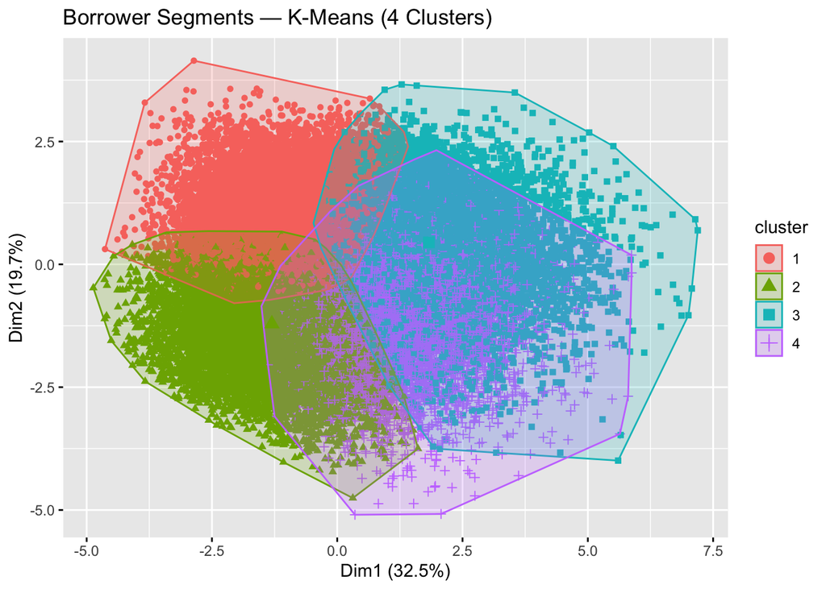

```r
# 2D cluster plot using PCA to compress 8 dimensions into 2 for visualisation
fviz_cluster(final_kmeans, data = df_scaled,
             geom = "point", ellipse.type = "convex") +
  labs(title = "Borrower Segments — K-Means (4 Clusters)")
```

Four distinct borrower profiles emerged from the clustering. Prime Borrowers are the lowest-risk group — low DTI, low utilisation, and the cheapest interest rates because the market prices their reliability. The Strugglers are the largest and most financially stressed segment — lowest income, cards nearly maxed out, and elevated interest rates reflecting that stress. Wealthy but Aggressive is the most interesting finding: high incomes that might suggest safety, but paired with very large loans and high revolving balances — the market has already priced in this risk with the highest rates in the portfolio. High Debt-Burden borrowers look similar to Prime on income but carry a much heavier existing debt load, making their free cash flow far tighter than the income figure alone would suggest.

# STEP 5: Merge Clusters Back and Compare Policy A vs Policy B

```r
# Make sure both cluster ID and segment name are in cluster_data_clean
cluster_data_clean$cluster_num <- final_kmeans$cluster
cluster_data_clean$Segment     <- cluster_labels[as.character(final_kmeans$cluster)]

# Join segment labels back to the full dataset using row_id.
# Safe approach — avoids the index mismatch that would occur if we used
# [-outliers, ] on df_clean. inner_join keeps only rows that survived all
# filtering steps. df_clean carries all financial columns including net_return.
valid_rows <- df_clean %>%
  inner_join(
    cluster_data_clean %>% select(row_id, cluster_num, Segment),
    by = "row_id"
  )

# Convert outcome to numeric and define both policies.
# grade cast to character so %in% works reliably on factor columns.
valid_rows <- valid_rows %>%
  mutate(
    default_flag      = as.numeric(loan_is_bad),
    grade             = as.character(grade),
    # Policy A — lenient: DTI <= 30, grades A-F, up to 1 delinquency
    policy_a_approved = ifelse(
      dti <= 30 & grade %in% c("A","B","C","D","E","F") & delinq_2yrs <= 1,
      1, 0),
    # Policy B — strict: DTI <= 20, grades A-C only, zero delinquencies
    policy_b_approved = ifelse(
      dti <= 20 & grade %in% c("A","B","C") & delinq_2yrs == 0,
      1, 0),
    # Net return per application for each policy
    # Rejected applications assigned zero — same definition as Q1 primary OEC
    net_return_A = ifelse(policy_a_approved == 1, net_return, 0),
    net_return_B = ifelse(policy_b_approved == 1, net_return, 0)
  )

# For each segment: default rate, approval rates, FPR, FNR, and net return
# for both policies. This allows direct comparison of financial performance
# by segment — not just risk metrics.
policy_comparison <- valid_rows %>%
  group_by(Segment) %>%
  summarise(
    n                = n(),
    default_rate_pct = round(mean(default_flag, na.rm = TRUE) * 100, 1),

    # Policy A metrics
    A_approval_rate    = round(mean(policy_a_approved, na.rm = TRUE) * 100, 1),
    A_FPR              = round(sum(policy_a_approved == 1 & default_flag == 1) /
                                 sum(default_flag == 1) * 100, 1),
    A_FNR              = round(sum(policy_a_approved == 0 & default_flag == 0) /
                                 sum(default_flag == 0) * 100, 1),
    # Primary OEC: avg net return per application (zero for rejections)
    A_net_return       = round(mean(net_return_A, na.rm = TRUE), 2),

    # Policy B metrics
    B_approval_rate    = round(mean(policy_b_approved, na.rm = TRUE) * 100, 1),
    B_FPR              = round(sum(policy_b_approved == 1 & default_flag == 1) /
                                 sum(default_flag == 1) * 100, 1),
    B_FNR              = round(sum(policy_b_approved == 0 & default_flag == 0) /
                                 sum(default_flag == 0) * 100, 1),
    # Primary OEC: avg net return per application (zero for rejections)
    B_net_return       = round(mean(net_return_B, na.rm = TRUE), 2),

    .groups = "drop"
  )

print("Policy A vs Policy B — Performance by Borrower Segment:")
```

```
## [1] "Policy A vs Policy B — Performance by Borrower Segment:"
```

```r
print(policy_comparison, width = Inf)
```

```
## # A tibble: 4 × 11
##   Segment                    n default_rate_pct A_approval_rate A_FPR A_FNR
##   <chr>                  <int>            <dbl>           <dbl> <dbl> <dbl>
## 1 High Debt-Burden       10934             15.3            81.3  78.3  18.1
## 2 Prime Borrowers        11046              9.8            96.2  94.7   3.6
## 3 The Strugglers         17142             18.3            90.9  89.9   8.9
## 4 Wealthy but Aggressive 10272             17.8            88.6  85.6  10.8
##   A_net_return B_approval_rate B_FPR B_FNR B_net_return
##          <dbl>           <dbl> <dbl> <dbl>        <dbl>
## 1         780.            27.3  19.7  71.3         291.
## 2         733.            77.7  71.5  21.6         587.
## 3         774.            38.2  31.7  60.3         344.
## 4        1698.            29.8  17    67.4         562.
```

```r
income_raw <- df_clean %>%
  inner_join(
    cluster_data_clean %>% select(row_id, Segment),
    by = "row_id"
  ) %>%
  group_by(Segment) %>%
  summarise("Avg Income ($)" = round(mean(annual_inc, na.rm = TRUE), 0))
```

```r
# ── Combined profile + default rate table (for report)
cluster_summary <- cluster_profile_named %>%
  left_join(
    policy_comparison %>% select(Segment, default_rate_pct),
    by = "Segment"
  ) %>%
  left_join(income_raw, by = "Segment") %>%
  rename(
    "N"                   = n_borrowers,
    "Avg Loan ($)"        = avg_loan,
    "Avg DTI (%)"         = avg_dti,
    "Avg Int Rate (%)"    = avg_int_rate,
    "Avg Utilisation (%)" = avg_utilization,
    "Default Rate (%)"    = default_rate_pct
  ) %>%
  select(Segment, N, `Avg Income ($)`, `Avg Loan ($)`,
         `Avg DTI (%)`, `Avg Int Rate (%)`,
         `Avg Utilisation (%)`, `Default Rate (%)`) %>%
  arrange(`Default Rate (%)`)

knitr::kable(cluster_summary)
```

[output not shown]

```r
print(cluster_summary, width = Inf)
```

```
## # A tibble: 4 × 8
##   Segment                    N `Avg Income ($)` `Avg Loan ($)` `Avg DTI (%)`
##   <chr>                  <int>            <dbl>          <dbl>         <dbl>
## 1 Prime Borrowers        11046            69898          11207          10.8
## 2 High Debt-Burden       10934            69685          12821          21.9
## 3 Wealthy but Aggressive 10272           102912          24111          17.9
## 4 The Strugglers         17142            48742          10062          18.5
##   `Avg Int Rate (%)` `Avg Utilisation (%)` `Default Rate (%)`
##                <dbl>                 <dbl>              <dbl>
## 1               10.5                  33.1                9.8
## 2               13.4                  55.3               15.3
## 3               16.8                  70.9               17.8
## 4               15                    70.7               18.3
```

# STEP 6: Visualisations

## Figure 2a — Default Rate by Borrower Segment

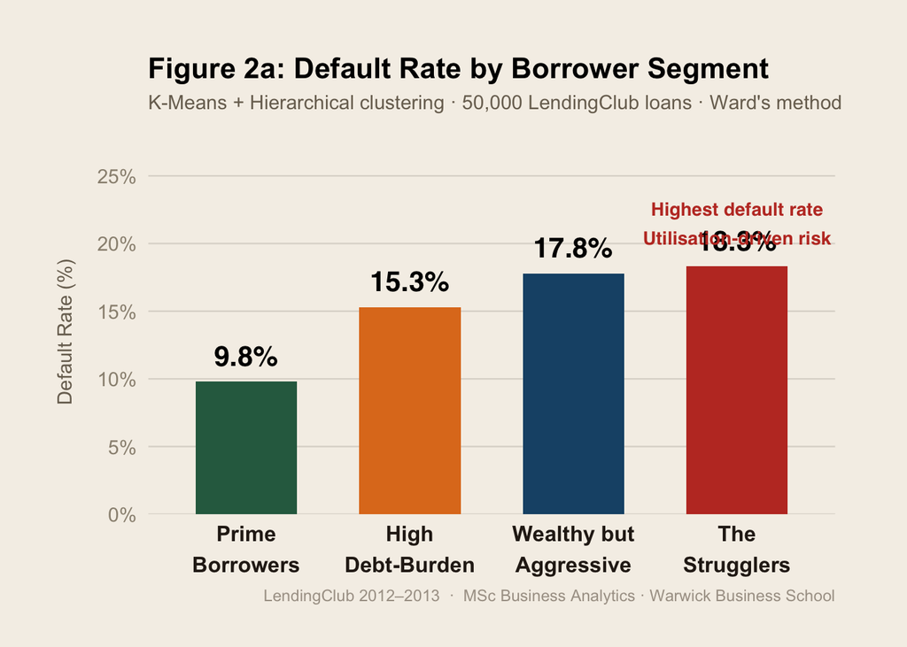

```r
seg_order <- c("Prime Borrowers", "High Debt-Burden",
               "Wealthy but Aggressive", "The Strugglers")

seg_colours <- c(
  "Prime\nBorrowers"        = "#2d6a4f",
  "High\nDebt-Burden"       = "#e07b20",
  "Wealthy but\nAggressive" = "#1a5276",
  "The\nStrugglers"         = "#c0392b"
)

segment_data <- data.frame(
  Segment     = c("Prime\nBorrowers", "High\nDebt-Burden",
                  "Wealthy but\nAggressive", "The\nStrugglers"),
  DefaultRate = c(9.8, 15.3, 17.8, 18.3)
)
segment_data$Segment <- factor(segment_data$Segment,
                                levels = names(seg_colours))

p_default <- ggplot(segment_data,
                    aes(x = Segment, y = DefaultRate, fill = Segment)) +
  geom_col(width = 0.62, show.legend = FALSE) +
  geom_text(aes(label = paste0(DefaultRate, "%")),
            vjust = -0.8, fontface = "bold", size = 5.5, family = "sans") +
  annotate("text",
           x = "The\nStrugglers", y = 21.5,
           label = "Highest default rate\nUtilisation-driven risk",
           colour = "#c0392b", size = 3.6, fontface = "bold",
           lineheight = 1.3, family = "sans") +
  scale_fill_manual(values = seg_colours) +
  scale_y_continuous(limits = c(0, 25), breaks = seq(0, 25, 5),
                     labels = function(x) paste0(x, "%"),
                     expand = expansion(mult = c(0, 0.08))) +
  labs(title    = "Figure 2a: Default Rate by Borrower Segment",
       subtitle = "K-Means + Hierarchical clustering · 50,000 LendingClub loans · Ward's method",
       x = NULL, y = "Default Rate (%)",
       caption = "LendingClub 2012–2013  ·  MSc Business Analytics · Warwick Business School") +
  theme_minimal(base_size = 14) +
  theme(
    plot.title         = element_text(face = "bold", size = 16, hjust = 0,
                                      colour = "black", margin = margin(b = 6)),
    plot.subtitle      = element_text(colour = "#7a6f60", size = 11, hjust = 0,
                                      margin = margin(b = 20)),
    plot.caption       = element_text(colour = "#aaa095", size = 9, hjust = 1),
    plot.background    = element_rect(fill = "#f5f0e8", colour = NA),
    panel.background   = element_rect(fill = "#f5f0e8", colour = NA),
    panel.grid.major.x = element_blank(),
    panel.grid.minor   = element_blank(),
    panel.grid.major.y = element_line(colour = "#ddd8d0", linewidth = 0.4),
    axis.text.x        = element_text(face = "bold", size = 12,
                                      colour = "#2a2018", lineheight = 1.2),
    axis.text.y        = element_text(colour = "#9a9080", size = 11),
    axis.title.y       = element_text(colour = "#7a6f60", size = 11,
                                      margin = margin(r = 12)),
    plot.margin        = margin(32, 40, 24, 32)
  )

ggsave("fig2a_default_rate.png", p_default,
       width = 9, height = 7, dpi = 180, bg = "#f5f0e8")
print(p_default)
```

## Figure 2b — Policy Performance by Borrower Segment (Approval Rate, FPR, FNR, Net Return)

```r
# ── Segment colours — solid = Policy A, lighter tint = Policy B ──────────────
seg_cols_named <- c(
  "Prime Borrowers"        = "#2d6a4f",
  "High Debt-Burden"       = "#e07b20",
  "Wealthy but Aggressive" = "#1a5276",
  "The Strugglers"         = "#c0392b"
)

# Helper: lighten a colour by blending with white
lighten <- function(col, amount = 0.52) {
  v <- col2rgb(col) / 255
  rgb(v[1] + (1-v[1])*amount,
      v[2] + (1-v[2])*amount,
      v[3] + (1-v[3])*amount)
}

# Build named fill vector: SegmentName_A (solid) and SegmentName_B (tinted)
fill_vals <- c(
  setNames(seg_cols_named,
           paste0(names(seg_cols_named), "_A")),
  setNames(sapply(seg_cols_named, lighten),
           paste0(names(seg_cols_named), "_B"))
)

# ── Long-format data from policy_comparison ───────────────────────────────────
seg_order2 <- c("Prime Borrowers", "High Debt-Burden",
                "Wealthy but Aggressive", "The Strugglers")

long_data <- policy_comparison %>%
  select(Segment,
         A_approval_rate, B_approval_rate,
         A_FPR, B_FPR,
         A_FNR, B_FNR,
         A_net_return, B_net_return) %>%
  mutate(Segment = factor(Segment, levels = seg_order2)) %>%
  pivot_longer(
    cols      = -Segment,
    names_to  = c("Policy", "Metric"),
    names_sep = "_",
    values_to = "Value"
  ) %>%
  mutate(
    Policy     = ifelse(Policy == "A", "Policy A", "Policy B"),
    Metric     = recode(Metric,
                        "approval" = "Approval Rate",
                        "FPR"      = "FPR",
                        "FNR"      = "FNR",
                        "net"      = "Net Return (£)"),
    Metric     = factor(Metric,
                        levels = c("Approval Rate","FPR","FNR","Net Return (£)")),
    fill_group = paste0(as.character(Segment), "_",
                        ifelse(Policy == "Policy A", "A", "B"))
  )
```

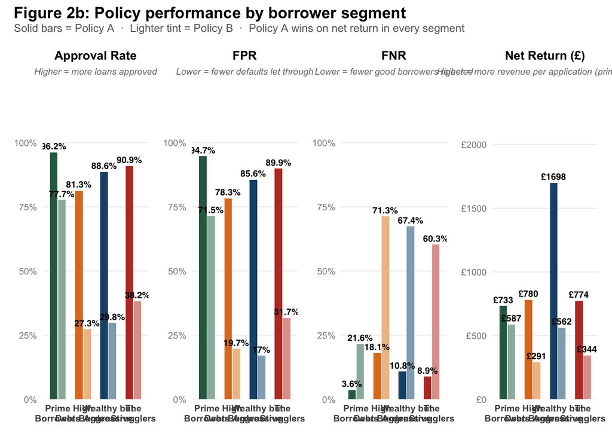

```r
subtitles <- c(
  "Approval Rate" = "Higher = more loans approved",
  "FPR"           = "Lower = fewer defaults let through",
  "FNR"           = "Lower = fewer good borrowers rejected",
  "Net Return (£)"= "Higher = more revenue per application (primary OEC)"
)

# ── Helper: build one panel ───────────────────────────────────────────────────
make_panel <- function(metric_name, is_gbp = FALSE) {
  d <- long_data %>%
    filter(Metric == metric_name) %>%
    mutate(Policy = factor(Policy, levels = c("Policy A", "Policy B")))

  y_max <- if (is_gbp) max(d$Value) * 1.4 else 118

  # lbl_fn defined but label applied directly in geom_text below

  ggplot(d, aes(x = Segment, y = Value,
                fill = fill_group, group = Policy)) +
    geom_col(position = position_dodge(width = 0.65),
             width = 0.6, show.legend = FALSE) +
    geom_text(aes(label = if (is_gbp) paste0("£", round(Value, 0))
                          else paste0(Value, "%")),
              position = position_dodge(width = 0.65),
              vjust = -0.5, fontface = "bold",
              size = 2.6, family = "sans") +
    scale_fill_manual(values = fill_vals) +
    scale_y_continuous(
      limits = c(0, y_max),
      labels = if (is_gbp) function(x) paste0("£", round(x, 0))
               else        function(x) paste0(x, "%"),
      expand = expansion(mult = c(0, 0.05))
    ) +
    scale_x_discrete(labels = function(x)
      stringr::str_wrap(x, width = 12)) +
    labs(title    = metric_name,
         subtitle = subtitles[metric_name],
         x = NULL, y = NULL) +
    theme_minimal(base_size = 10) +
    theme(
      plot.title         = element_text(face = "bold", size = 10,
                                        hjust = 0.5, colour = "black"),
      plot.subtitle      = element_text(colour = "#777777", size = 7.5,
                                        hjust = 0.5, face = "italic",
                                        margin = margin(b = 4)),
      panel.grid.major.x = element_blank(),
      panel.grid.minor   = element_blank(),
      panel.grid.major.y = element_line(colour = "#EEEEEE", linewidth = 0.4),
      axis.text.x        = element_text(face = "bold", size = 7.5),
      axis.text.y        = element_text(colour = "#888888", size = 7.5),
      plot.background    = element_rect(fill = "white", colour = NA),
      panel.background   = element_rect(fill = "white", colour = NA),
      plot.margin        = margin(6, 6, 6, 6)
    )
}

p_appr   <- make_panel("Approval Rate")
p_fpr    <- make_panel("FPR")
p_fnr    <- make_panel("FNR")
p_return <- make_panel("Net Return (£)", is_gbp = TRUE)

# ── Policy legend (manual — solid vs tinted) ──────────────────────────────────
legend_df <- data.frame(
  x     = c(1, 2),
  y     = c(1, 1),
  group = c("solid", "tint"),
  label = c("Policy A (solid)", "Policy B (lighter tint)")
)

# ── Combine all four panels ────────────────────────────────────────────────────
fig2b <- (p_appr | p_fpr | p_fnr | p_return) +
  plot_annotation(
    title    = "Figure 2b: Policy performance by borrower segment",
    subtitle = paste0(
      "Solid bars = Policy A  ·  Lighter tint = Policy B  ·  ",
      "Policy A wins on net return in every segment"
    ),
    theme    = theme(
      plot.title    = element_text(face = "bold", size = 13, colour = "black",
                                   hjust = 0, margin = margin(b = 2)),
      plot.subtitle = element_text(colour = "#666666", size = 9, hjust = 0,
                                   margin = margin(b = 8)),
      plot.caption  = element_text(colour = "#AAAAAA", size = 8, hjust = 1),
      plot.background = element_rect(fill = "white", colour = NA)
    )
  )

ggsave("fig2b_policy_by_segment.png", fig2b,
       width = 14, height = 5, dpi = 180, bg = "white")
print(fig2b)
```

## Figure 2: Avg Net Return per Application by Borrower Segment

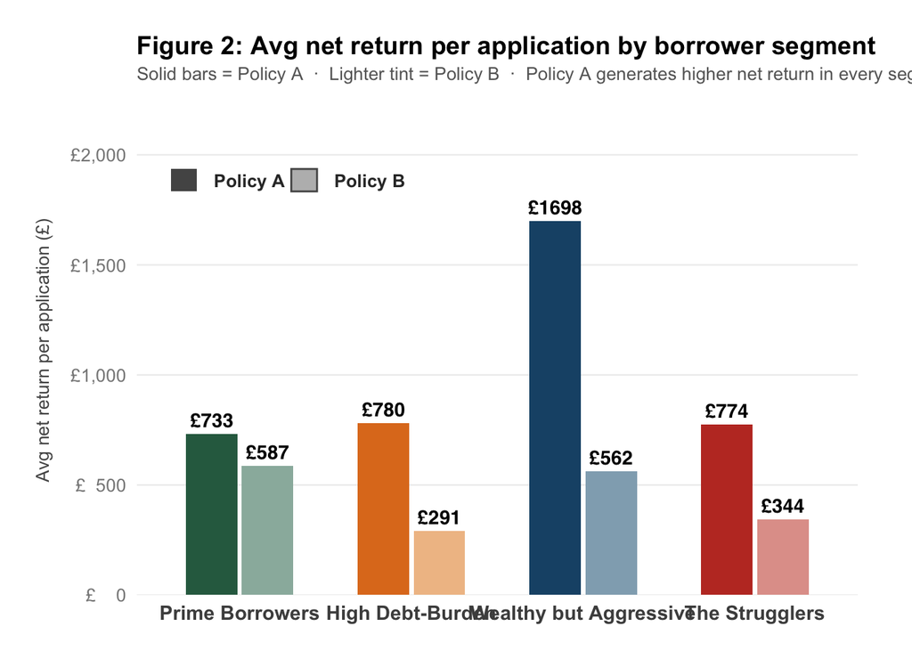

```r
# ── Segment colours — solid = Policy A, lighter tint = Policy B ──────────────
seg_cols <- c(
  "Prime Borrowers"        = "#2d6a4f",
  "High Debt-Burden"       = "#e07b20",
  "Wealthy but Aggressive" = "#1a5276",
  "The Strugglers"         = "#c0392b"
)

lighten <- function(col, amount = 0.52) {
  v <- col2rgb(col) / 255
  rgb(v[1] + (1-v[1])*amount,
      v[2] + (1-v[2])*amount,
      v[3] + (1-v[3])*amount)
}

# ── Long format — one row per segment per policy ──────────────────────────────
seg_order <- c("Prime Borrowers","High Debt-Burden",
               "Wealthy but Aggressive","The Strugglers")

net_data <- policy_comparison %>%
  select(Segment, A_net_return, B_net_return) %>%
  pivot_longer(
    cols      = c(A_net_return, B_net_return),
    names_to  = "Policy",
    values_to = "NetReturn"
  ) %>%
  mutate(
    Policy  = ifelse(Policy == "A_net_return", "Policy A", "Policy B"),
    Segment = factor(Segment, levels = seg_order),
    # Fill: solid colour for A, lighter tint for B
    fill_id = paste0(as.character(Segment), "_",
                     ifelse(Policy == "Policy A", "A", "B"))
  )

# Build named fill vector
fill_vals <- c(
  setNames(seg_cols,                  paste0(names(seg_cols), "_A")),
  setNames(sapply(seg_cols, lighten), paste0(names(seg_cols), "_B"))
)

# ── Plot ──────────────────────────────────────────────────────────────────────
p_net <- ggplot(net_data,
                aes(x = Segment, y = NetReturn,
                    fill = fill_id, group = Policy)) +

  geom_col(position = position_dodge(width = 0.65),
           width = 0.6, show.legend = FALSE) +

  geom_text(aes(label = paste0("£", round(NetReturn, 0))),
            position = position_dodge(width = 0.65),
            vjust = -0.5, fontface = "bold",
            size = 3.8, family = "sans") +

  scale_fill_manual(values = fill_vals) +

  scale_y_continuous(
    labels = function(x) paste0("£", format(round(x, 0), big.mark = ",")),
    expand = expansion(mult = c(0, 0.15))
  ) +

  # Manual legend using annotate
  annotate("rect", xmin = 3.6, xmax = 3.75, ymin = Inf, ymax = Inf,
           fill = "#555555") +

  labs(
    title    = "Figure 2: Avg net return per application by borrower segment",
    subtitle = paste0(
      "Solid bars = Policy A  ·  Lighter tint = Policy B  ·  ",
      "Policy A generates higher net return in every segment"
    ),
    x       = NULL,
    y       = "Avg net return per application (£)"
  ) +

  theme_minimal(base_size = 13) +
  theme(
    plot.title         = element_text(face = "bold", size = 14, colour = "black",
                                      hjust = 0, margin = margin(b = 4)),
    plot.subtitle      = element_text(colour = "#666666", size = 10, hjust = 0,
                                      margin = margin(b = 12)),
    plot.caption       = element_text(colour = "#AAAAAA", size = 9, hjust = 1),
    panel.grid.major.x = element_blank(),
    panel.grid.minor   = element_blank(),
    panel.grid.major.y = element_line(colour = "#EEEEEE", linewidth = 0.4),
    axis.text.x        = element_text(face = "bold", size = 11),
    axis.text.y        = element_text(colour = "#888888", size = 10),
    axis.title.y       = element_text(colour = "#555555", size = 10,
                                      margin = margin(r = 10)),
    plot.background    = element_rect(fill = "white", colour = NA),
    panel.background   = element_rect(fill = "white", colour = NA),
    plot.margin        = margin(20, 30, 15, 20)
  )

# Add a simple manual legend via annotation
p_net <- p_net +
  annotate("rect",
           xmin = 0.6, xmax = 0.75,
           ymin = max(net_data$NetReturn) * 1.08,
           ymax = max(net_data$NetReturn) * 1.14,
           fill = "#555555") +
  annotate("text",
           x    = 0.85,
           y    = max(net_data$NetReturn) * 1.11,
           label = "Policy A",
           hjust = 0, fontface = "bold", size = 3.5, colour = "#333333") +
  annotate("rect",
           xmin = 1.3, xmax = 1.45,
           ymin = max(net_data$NetReturn) * 1.08,
           ymax = max(net_data$NetReturn) * 1.14,
           fill = "#BBBBBB", colour = "#555555", linewidth = 0.5) +
  annotate("text",
           x    = 1.55,
           y    = max(net_data$NetReturn) * 1.11,
           label = "Policy B",
           hjust = 0, fontface = "bold", size = 3.5, colour = "#333333")

ggsave("fig2_net_return_by_segment.png", p_net,
       width = 10, height = 5.5, dpi = 180, bg = "white")
print(p_net)
```